# Assignment 3

Problem 1 - Predicting number of college applications 1. (1p) Download the dataset college.csv and explore its overall structure. Get a summary statistics of each variable. Answer the following questions: • How many observation do you have in the data? • How many categorical and numeric variables you have in your data?

```r
clg_df = read.csv("College.csv")
str(clg_df)
```

```
'data.frame':   777 obs. of  19 variables:
 $ X          : chr  "Abilene Christian University" "Adelphi University" "Adrian College" "Agnes Scott College" ...
 $ Private    : chr  "Yes" "Yes" "Yes" "Yes" ...
 $ Apps       : int  1660 2186 1428 417 193 587 353 1899 1038 582 ...
 $ Accept     : int  1232 1924 1097 349 146 479 340 1720 839 498 ...
 $ Enroll     : int  721 512 336 137 55 158 103 489 227 172 ...
 $ Top10perc  : int  23 16 22 60 16 38 17 37 30 21 ...
 $ Top25perc  : int  52 29 50 89 44 62 45 68 63 44 ...
 $ F.Undergrad: int  2885 2683 1036 510 249 678 416 1594 973 799 ...
 $ P.Undergrad: int  537 1227 99 63 869 41 230 32 306 78 ...
 $ Outstate   : int  7440 12280 11250 12960 7560 13500 13290 13868 15595 10468 ...
 $ Room.Board : int  3300 6450 3750 5450 4120 3335 5720 4826 4400 3380 ...
 $ Books      : int  450 750 400 450 800 500 500 450 300 660 ...
 $ Personal   : int  2200 1500 1165 875 1500 675 1500 850 500 1800 ...
 $ PhD        : int  70 29 53 92 76 67 90 89 79 40 ...
 $ Terminal   : int  78 30 66 97 72 73 93 100 84 41 ...
 $ S.F.Ratio  : num  18.1 12.2 12.9 7.7 11.9 9.4 11.5 13.7 11.3 11.5 ...
 $ perc.alumni: int  12 16 30 37 2 11 26 37 23 15 ...
 $ Expend     : int  7041 10527 8735 19016 10922 9727 8861 11487 11644 8991 ...
 $ Grad.Rate  : int  60 56 54 59 15 55 63 73 80 52 ...
```

There are 777 observations, 2 categorical variables and 17 numeric variables.

• Is there any missing value?

```r
sum(is.na(clg_df))
```

```
[1] 0
```

There appear to be no missing values in the dataset

2. (1pt) Remove the first column (the name of the college)

```r
clg_df = clg_df[,-1]
```

3. (2 pts) Which variables are associated with “Apps”. Use “pairs”, “cor”, and side by side box plot with t.test to answer this question.

```r
clg_df = as.data.frame(unclass(clg_df), stringsAsFactors = TRUE)
attach(clg_df)
```

Converting strings to factors and attaching the dataframe

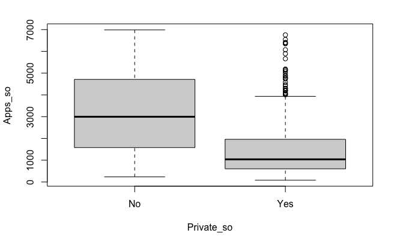

```r
iqr = 3264 - 776
iqr_index = (Apps > 776 - 1.5*iqr & Apps < 3264 + 1.5*iqr)
Apps_so = Apps[iqr_index] #so means sans outliers
Private_so = Private[iqr_index]
plot(Apps_so~Private_so)
```

```r
t.test(Apps_so~Private_so)
```

```
    Welch Two Sample t-test

data:  Apps_so by Private_so
t = 10.526, df = 192.83, p-value < 2.2e-16
alternative hypothesis: true difference in means is not equal to 0
95 percent confidence interval:
 1356.225 1981.677
sample estimates:
 mean in group No mean in group Yes
         3169.417          1500.466
```

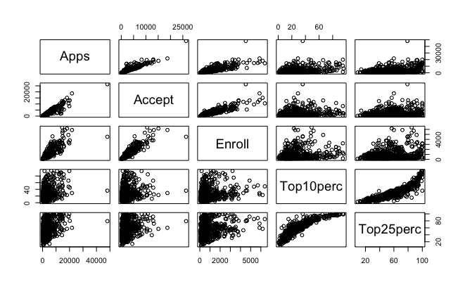

```r
pairs(clg_df[2:6])
```

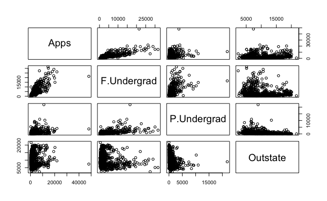

```r
pairs(clg_df[c(2,7:9)])
```

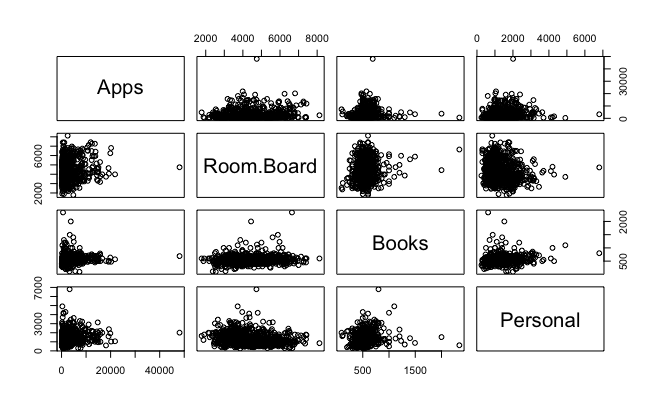

```r
pairs(clg_df[c(2,10:12)])
```

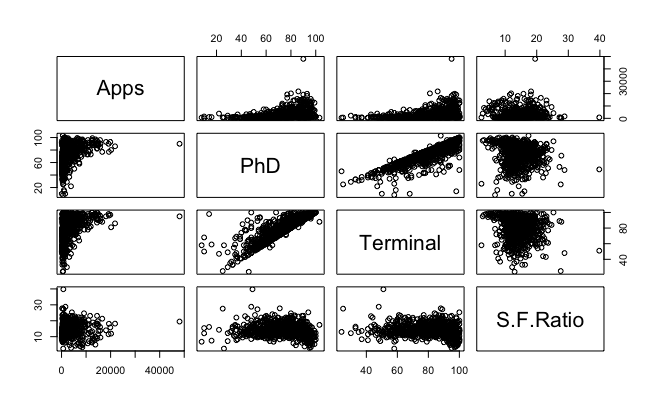

```r
pairs(clg_df[c(2,13:15)])
```

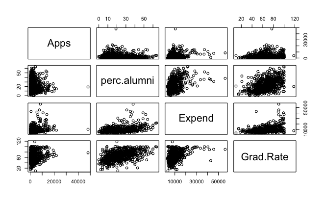

```r
pairs(clg_df[c(2,16:18)])
```

```r
cor(Apps, clg_df[ ,-c(1, 2)])
```

```
        Accept    Enroll Top10perc Top25perc F.Undergrad P.Undergrad   Outstate
[1,] 0.9434506 0.8468221 0.3388337 0.3516399   0.8144906   0.3982643 0.05015903
     Room.Board     Books  Personal       PhD  Terminal  S.F.Ratio perc.alumni   Expend
[1,]   0.164939 0.1325586 0.1787308 0.3906973 0.3694915 0.09563303 -0.09022589 0.259592
     Grad.Rate
[1,] 0.1467546
```

4. (1pt) plot the histogram of the number of applications “Apps” variable. Explain what the histogram shows?

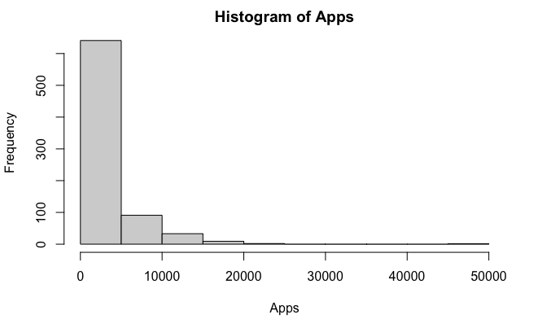

```r
hist(Apps)
```

Judging from the shape this historgram is right-skewed (possibly j-shaped if you see the small hump between 45k and 50k) with a mean between 0 and 10000

5. (1pt) replace the “Top10perc” variable with a factor variable “Elite” with two levels: “Yes” if 50% or more of new students coming from the top 10% of their high school class (that is, if Top10Perc>=50) , and “No” if less than 50% of new students are coming from the top10% of their high school class.

```r
clg_df$Elite = factor(ifelse(clg_df$Top10perc >= 50, "Yes", "No"))
clg_df = clg_df[-5]
```

6. (1pt) is the Elite variable you created above associated with the “Apps” variable? Don’t just say yes or no, you should explain your answer by plots and test statistics.

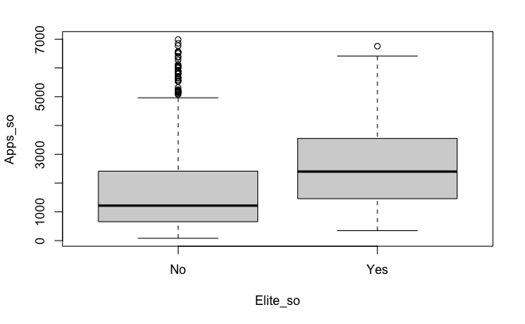

```r
Elite_so = clg_df$Elite[iqr_index]
plot(Apps_so~Elite_so)
```

```r
t.test(Apps_so~Elite_so)
```

```
    Welch Two Sample t-test

data:  Apps_so by Elite_so
t = -4.0472, df = 61.997, p-value = 0.0001462
alternative hypothesis: true difference in means is not equal to 0
95 percent confidence interval:
 -1357.147  -459.758
sample estimates:
 mean in group No mean in group Yes
         1796.751          2705.204
```

Based on the side-by-side box plot and the p-value = 0.01% < 5% it follows that Elite is associated with Apps

7. (1pt) normalize all numerical features (except the “Apps” variable) using z-score standardization using “scale” function

```r
clg_norm = as.data.frame(scale(clg_df[-c(1,2,18)], center=TRUE, scale=TRUE))
clg_norm$Private = clg_df$Private
clg_norm$Apps = clg_df$Apps
clg_norm$Elite = clg_df$Elite
```

8. set the random seed: set.seed(123)

```r
set.seed(123)
```

9. (2 pt) Use caret package to run 10 fold cross validation using linear regression method on all features.

Print the resulting model to see the cross validation RMSE. In addition, take a summary of the model and interpret the coefficients. Which coefficients are statistically different from zero? What does this meant?

```r
train.control = trainControl(method = "cv", number = 10)
model = train(Apps ~ ., data = clg_norm, method = "lm", trControl = train.control)
```

```r
model
```

```
Linear Regression

777 samples
 17 predictor

No pre-processing
Resampling: Cross-Validated (10 fold)
Summary of sample sizes: 699, 698, 699, 700, 700, 700, ...
Resampling results:

  RMSE      Rsquared   MAE
  1138.158  0.9125576  607.1512

Tuning parameter 'intercept' was held constant at a value of TRUE
```

```r
summary(model)
```

```
Call:
lm(formula = .outcome ~ ., data = dat)

Residuals:
    Min      1Q  Median      3Q     Max
-4763.7  -373.4   -10.9   246.5  8348.7

Coefficients:
            Estimate Std. Error t value Pr(>|t|)
(Intercept)  3172.31     114.55  27.693  < 2e-16 ***
Accept       3786.69     101.90  37.162  < 2e-16 ***
Enroll       -716.06     177.31  -4.038 5.93e-05 ***
Top25perc     214.07      60.22   3.555 0.000402 ***
F.Undergrad   313.18     163.69   1.913 0.056097 .
P.Undergrad    50.09      50.35   0.995 0.320082
Outstate     -314.84      78.88  -3.991 7.21e-05 ***
Room.Board    140.51      54.57   2.575 0.010223 *
Books          13.79      40.52   0.340 0.733603
Personal       27.84      43.99   0.633 0.526976
PhD           -44.75      77.50  -0.577 0.563807
Terminal     -119.51      76.74  -1.557 0.119803
S.F.Ratio      48.29      53.07   0.910 0.363207
perc.alumni    13.27      52.35   0.253 0.800009
Expend        512.53      64.62   7.932 7.73e-15 ***
Grad.Rate     168.06      52.10   3.226 0.001311 **
PrivateYes   -376.47     143.09  -2.631 0.008688 **
EliteYes      964.97     170.92   5.646 2.32e-08 ***
---
Signif. codes:  0 ‘***’ 0.001 ‘**’ 0.01 ‘*’ 0.05 ‘.’ 0.1 ‘ ’ 1

Residual standard error: 1073 on 759 degrees of freedom
Multiple R-squared:  0.9249,    Adjusted R-squared:  0.9232
F-statistic: 549.6 on 17 and 759 DF,  p-value: < 2.2e-16
```

10. Set the random seed again. We need to do this before each training to ensure we get the same folds in cross validation. Set.seed(123) so we can compare the models using their cross validation RMSE.

```r
set.seed(123)
```

11. (3 pts) Use caret and leap packages to run a 10 fold cross validation using step wise linear regression method with backward selection (i.e., method=”leapBackward). The train method by default uses maximum of 4 predictors and reports the best models with 1..4 predictors. We need to change this parameter to consider 1..16 predictors. So inside your train function, add the following parameter tuneGrid = data.frame(nvmax = 1:16) . Which model (with how many variables or nvmax ) has the lowest RMSE. Take the summary of the final model to see which variables are selected in the model with the lowest RMSE?

```r
train.control = trainControl(method = "cv", number = 10)
step.model = train(Apps ~ ., data = clg_norm, method = "leapBackward", trControl = train.control, tuneGrid = data.frame(nvmax = 1:16))
```

```r
step.model
```

```
Linear Regression with Backwards Selection

777 samples
 17 predictor

No pre-processing
Resampling: Cross-Validated (10 fold)
Summary of sample sizes: 699, 698, 699, 700, 700, 700, ...
Resampling results across tuning parameters:

  nvmax  RMSE      Rsquared   MAE
   1     1268.944  0.8822559  609.7250
   2     1203.846  0.8997070  596.8906
   3     1128.262  0.9131422  583.0240
   4     1129.539  0.9139377  571.5753
   5     1150.446  0.9102549  584.3353
   6     1142.659  0.9113777  590.9501
   7     1144.105  0.9106873  594.9557
   8     1139.085  0.9116280  600.7066
   9     1133.949  0.9124540  604.8722
  10     1145.246  0.9118987  610.6895
  11     1132.981  0.9138866  604.3482
  12     1138.314  0.9128802  608.8777
  13     1139.644  0.9126223  609.0641
  14     1140.470  0.9124329  609.5907
  15     1138.520  0.9125139  608.2389
  16     1138.694  0.9124566  607.8491

RMSE was used to select the optimal model using the smallest value.
The final value used for the model was nvmax = 3.
```

```r
summary(step.model$finalModel)
```

```
Subset selection object
17 Variables  (and intercept)
            Forced in Forced out
Accept          FALSE      FALSE
Enroll          FALSE      FALSE
Top25perc       FALSE      FALSE
F.Undergrad     FALSE      FALSE
P.Undergrad     FALSE      FALSE
Outstate        FALSE      FALSE
Room.Board      FALSE      FALSE
Books           FALSE      FALSE
Personal        FALSE      FALSE
PhD             FALSE      FALSE
Terminal        FALSE      FALSE
S.F.Ratio       FALSE      FALSE
perc.alumni     FALSE      FALSE
Expend          FALSE      FALSE
Grad.Rate       FALSE      FALSE
PrivateYes      FALSE      FALSE
EliteYes        FALSE      FALSE
1 subsets of each size up to 3
Selection Algorithm: backward
         Accept Enroll Top25perc F.Undergrad P.Undergrad Outstate Room.Board Books
1  ( 1 ) "*"    " "    " "       " "         " "         " "      " "        " "
2  ( 1 ) "*"    " "    " "       " "         " "         " "      " "        " "
3  ( 1 ) "*"    " "    " "       " "         " "         " "      " "        " "
         Personal PhD Terminal S.F.Ratio perc.alumni Expend Grad.Rate PrivateYes
1  ( 1 ) " "      " " " "      " "       " "         " "    " "       " "
2  ( 1 ) " "      " " " "      " "       " "         " "    " "       " "
3  ( 1 ) " "      " " " "      " "       " "         "*"    " "       " "
         EliteYes
1  ( 1 ) " "
2  ( 1 ) "*"
3  ( 1 ) "*"
```

Accept, Expend, and EliteYes were selected

12. (2 pt) Split the data into train and test ( you can use the first 621 rows for training and rest for testing). use “rpart” function to create a regression tree model from the training data. Get the predictions on testing data and compute the RMSE.

```r
clg_train = clg_df[1:621, ]
clg_test = clg_df[622:777, ]
m.rpart = rpart(Apps ~ ., data = clg_train)
p.rpart = predict(m.rpart, clg_test)
(mean((clg_test$Apps - p.rpart)^2))^0.5
```

```
[1] 1448.415
```

The RMSE is 1448.4

Problem 2 - Predicting loan default 1- Set the random seed, set.seed(123), and split the data to train/test as we did in slide 37 of week6 lectures.

```r
credit = read.csv("credit.csv", stringsAsFactors = TRUE)
credit_norm = as.data.frame(scale(credit[-c(1,3,4,6,7,11,12,14,16,17)], center=TRUE, scale=TRUE))
credit_norm$checking_balance = credit$checking_balance
credit_norm$credit_history = credit$credit_history
credit_norm$purpose = credit$purpose
credit_norm$savings_balance = credit$savings_balance
credit_norm$employment_duration = credit$employment_duration
credit_norm$other_credit = credit$other_credit
credit_norm$housing = credit$housing
credit_norm$job = credit$job
credit_norm$phone = credit$phone
```

```r
set.seed(123)
train_sample <- sample(1000, 900)
credit_train <- credit[train_sample, ]
credit_test <- credit[-train_sample, ]
```

2- (2pt) Train a logistic regression model on the train data using the glm function and use it to predict the default for the test data

```r
summary(logistic_model)
```

[output not shown]

```
Call:
glm(formula = default ~ ., family = "binomial", data = credit_train)

Deviance Residuals:
    Min       1Q   Median       3Q      Max
-1.9549  -0.7457  -0.4111   0.7894   2.6125

Coefficients:
                                 Estimate Std. Error z value Pr(>|z|)
(Intercept)                    -2.111e+00  9.577e-01  -2.205 0.027476 *
checking_balance> 200 DM       -8.629e-01  3.753e-01  -2.299 0.021492 *
checking_balance1 - 200 DM     -4.202e-01  2.170e-01  -1.936 0.052851 .
checking_balanceunknown        -1.740e+00  2.376e-01  -7.325 2.38e-13 ***
months_loan_duration            2.978e-02  9.241e-03   3.223 0.001270 **
credit_historygood              7.602e-01  2.695e-01   2.821 0.004785 **
credit_historyperfect           1.310e+00  4.374e-01   2.995 0.002747 **
credit_historypoor              6.774e-01  3.382e-01   2.003 0.045180 *
credit_historyvery good         1.501e+00  4.314e-01   3.478 0.000505 ***
purposecar                      2.836e-01  3.265e-01   0.868 0.385136
purposecar0                    -8.700e-01  8.416e-01  -1.034 0.301215
purposeeducation                5.406e-01  4.520e-01   1.196 0.231667
purposefurniture/appliances    -1.083e-01  3.208e-01  -0.338 0.735530
purposerenovations              6.899e-01  6.143e-01   1.123 0.261459
amount                          1.043e-04  4.372e-05   2.386 0.017047 *
savings_balance> 1000 DM       -1.113e+00  5.058e-01  -2.201 0.027735 *
savings_balance100 - 500 DM    -2.818e-01  2.870e-01  -0.982 0.326228
savings_balance500 - 1000 DM   -3.550e-01  4.027e-01  -0.882 0.378031
savings_balanceunknown         -9.398e-01  2.721e-01  -3.454 0.000552 ***
employment_duration> 7 years   -5.599e-01  2.993e-01  -1.870 0.061423 .
employment_duration1 - 4 years -2.883e-01  2.399e-01  -1.202 0.229328
employment_duration4 - 7 years -1.112e+00  3.091e-01  -3.597 0.000322 ***
employment_durationunemployed   1.038e-02  4.348e-01   0.024 0.980960
percent_of_income               3.669e-01  8.893e-02   4.125 3.70e-05 ***
years_at_residence             -1.704e-03  8.828e-02  -0.019 0.984597
age                            -1.211e-02  9.252e-03  -1.309 0.190622
other_creditnone               -4.831e-01  2.396e-01  -2.016 0.043818 *
other_creditstore              -3.568e-01  4.453e-01  -0.801 0.423000
housingown                     -1.740e-01  3.005e-01  -0.579 0.562578
housingrent                     3.242e-01  3.446e-01   0.941 0.346753
existing_loans_count            3.016e-01  2.015e-01   1.496 0.134542
jobskilled                      2.152e-01  2.964e-01   0.726 0.467813
jobunemployed                  -7.401e-02  6.686e-01  -0.111 0.911856
jobunskilled                    1.842e-01  3.582e-01   0.514 0.607175
dependents                      1.329e-01  2.436e-01   0.546 0.585389
phoneyes                       -2.470e-01  2.049e-01  -1.206 0.227919
---
Signif. codes:  0 ‘***’ 0.001 ‘**’ 0.01 ‘*’ 0.05 ‘.’ 0.1 ‘ ’ 1

(Dispersion parameter for binomial family taken to be 1)

    Null deviance: 1090.95  on 899  degrees of freedom
Residual deviance:  847.31  on 864  degrees of freedom
AIC: 919.31

Number of Fisher Scoring iterations: 5
```

3- (2pt)Compare the predictions with the actual default labels in the test data. What is the false positive rate and false negative rate of your model? How does your logistic regression model compare with the classification models we used in week 6 lectures?

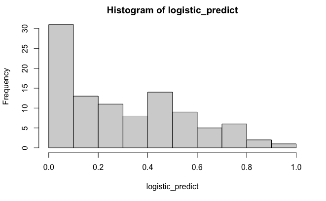

```r
hist(logistic_predict)
```

```r
predicted.label = factor(ifelse(logistic_predict > 0.5, "no", "yes"))
actual.label = credit_test$default
t = table(predicted.label, actual.label)
t
```

```
               actual.label
predicted.label no yes
            no   7  16
            yes 58  19
```

```r
error = (t[1,2] + t[2,1])/sum(t)
print(paste("the error is" ,formatC(error*100,digits = 3),"%"))
```

```
[1] "the error is   74 %"
```

```r
fpr = (t[1,2]/(t[1,2] + t[2,2]))
print(paste("false positive rate:",formatC(fpr*100,digits = 3),"%"))
```

```
[1] "false positive rate: 45.7 %"
```

```r
fnr = (t[2,1]/(t[2,1]+t[2,2]))
print(paste("false negative rate:",formatC(fnr*100,digits = 3),"%"))
```

```
[1] "false negative rate: 75.3 %"
```

With an error of 74% I’d say that this model is considerably worse at predicting defaults that the model used in lecture 6 with its error rate of 27%

4- (6pt) The outcome variable “default” is imbalanced that is, the number of observations with default=NO is double the number of observations with default=Yes. Most classification models trained on imbalanced data are biased towards predicting the majority class and yield a higher classification error on the minority class. One way to deal with class imbalance problem is to downsample the majority class; meaning randomly sample the observations in the majority class to make it the same size as the minority class. While this approach might work for larger dataset with large enough samples in the minority class, for smaller dataset, it will result in loss of information. Another approach to deal with class imbalance is to use oversampling; meaning generating syntactic samples and add it to the minority class to make it the same size as the majority class. A popular method for generating syntactic samples is called SMOTE (Syntactic Minority Oversampling Technique) which uses KNN to generate syntactic samples for the minority class. Please watch this short Youtube video to understand SMOTE, Then install DMwR package in R and use the SMOTE function to generate syntactic training data for the minority class. Please note that oversampling or under-sampling should only be applied to the training data and the testing data should be untouched. Use perc.over=100 argument in the SMOTE function and leave the other parameters as default to create a balanced training data. Then train a logistic regression model on this balanced data and evaluate it on your test data. Compare the False Positive and the False Negative Rates of the model trained on the balanced data to your previous model trained on the imbalance data and discuss the differences.

```r
install.packages("DMwR")
library(DMwR)
```

```r
set.seed(123)
credit_smote = SMOTE(default ~ ., data = credit_train, perc.over = 100)
log_model_smote = glm(default~., data = credit_smote, family = "binomial")
summary(log_model_smote)
```

```
Call:
glm(formula = default ~ ., family = "binomial", data = credit_smote)

Deviance Residuals:
     Min        1Q    Median        3Q       Max
-2.46173  -0.86223  -0.00783   0.86043   2.54526

Coefficients:
                                 Estimate Std. Error z value Pr(>|z|)
(Intercept)                    -1.141e+00  8.063e-01  -1.415 0.157137
checking_balance> 200 DM       -3.684e-01  3.280e-01  -1.123 0.261393
checking_balance1 - 200 DM     -1.675e-01  1.921e-01  -0.872 0.383208
checking_balanceunknown        -1.389e+00  1.980e-01  -7.017 2.27e-12 ***
months_loan_duration            2.919e-02  8.445e-03   3.457 0.000546 ***
credit_historygood              8.335e-01  2.177e-01   3.828 0.000129 ***
credit_historyperfect           1.287e+00  3.948e-01   3.260 0.001115 **
credit_historypoor              9.262e-01  2.781e-01   3.331 0.000866 ***
credit_historyvery good         1.941e+00  3.513e-01   5.525 3.29e-08 ***
purposecar                     -1.377e-01  2.718e-01  -0.507 0.612421
purposecar0                     6.316e-01  7.613e-01   0.830 0.406731
purposeeducation                3.755e-01  3.979e-01   0.944 0.345256
purposefurniture/appliances    -4.895e-01  2.675e-01  -1.830 0.067237 .
purposerenovations             -1.309e-01  5.333e-01  -0.245 0.806123
amount                          1.661e-04  4.041e-05   4.110 3.96e-05 ***
savings_balance> 1000 DM       -1.094e+00  4.149e-01  -2.636 0.008386 **
savings_balance100 - 500 DM     1.083e-01  2.515e-01   0.431 0.666600
savings_balance500 - 1000 DM   -1.335e-01  3.235e-01  -0.413 0.679742
savings_balanceunknown         -5.766e-01  2.135e-01  -2.700 0.006929 **
employment_duration> 7 years   -7.206e-01  2.506e-01  -2.876 0.004028 **
employment_duration1 - 4 years -5.719e-01  2.159e-01  -2.649 0.008074 **
employment_duration4 - 7 years -1.444e+00  2.758e-01  -5.234 1.66e-07 ***
employment_durationunemployed   3.301e-01  3.732e-01   0.884 0.376461
percent_of_income               4.006e-01  8.156e-02   4.912 9.00e-07 ***
years_at_residence              1.126e-02  7.956e-02   0.142 0.887408
age                            -6.277e-03  8.127e-03  -0.772 0.439893
other_creditnone               -5.040e-01  2.047e-01  -2.463 0.013787 *
other_creditstore               5.358e-01  3.863e-01   1.387 0.165439
housingown                     -4.717e-01  2.518e-01  -1.874 0.060986 .
housingrent                     2.412e-01  2.945e-01   0.819 0.412758
existing_loans_count            3.286e-01  1.722e-01   1.908 0.056385 .
jobskilled                      1.524e-01  2.274e-01   0.670 0.502603
jobunemployed                  -1.154e+00  5.830e-01  -1.979 0.047840 *
jobunskilled                    2.630e-01  2.724e-01   0.965 0.334431
dependents                     -1.498e-01  2.158e-01  -0.694 0.487506
phoneyes                       -3.768e-01  1.635e-01  -2.304 0.021215 *
---
Signif. codes:  0 ‘***’ 0.001 ‘**’ 0.01 ‘*’ 0.05 ‘.’ 0.1 ‘ ’ 1

(Dispersion parameter for binomial family taken to be 1)

    Null deviance: 1469.5  on 1059  degrees of freedom
Residual deviance: 1108.5  on 1024  degrees of freedom
AIC: 1180.5

Number of Fisher Scoring iterations: 4
```

```r
log_predict_smote = predict(log_model_smote, credit_test, type = "response")
```

```r
predicted.label = factor(ifelse(log_predict_smote > 0.5, "no", "yes"))
actual.label = credit_test$default
t = table(predicted.label, actual.label)
t
```

```
               actual.label
predicted.label no yes
            no  16  23
            yes 49  12
```

```r
error = (t[1,2] + t[2,1])/sum(t)
print(paste("the error is" ,formatC(error*100,digits = 3),"%"))
```

```
[1] "the error is   72 %"
```

```r
fpr = (t[1,2]/(t[1,2] + t[2,2]))
print(paste("false positive rate:",formatC(fpr*100,digits = 3),"%"))
```

```
[1] "false positive rate: 65.7 %"
```

```r
fnr = (t[2,1]/(t[2,1]+t[2,2]))
print(paste("false negative rate:",formatC(fnr*100,digits = 3),"%"))
```

```
[1] "false negative rate: 80.3 %"
```

The fpr and fnr are higher for the smote model than the model trained with the unmodified training data however the error is a bit less. Overall there isn’t really an improvement with smote data over the original data. I suppose varying perc.over and perc.under until better results are yielded would be a better way to go about improving model performance (this is assuming you’re being mindful not to overfit)